# entregable

1. ¿Cómo se llama por convención el archivo de requisitos?

   En el ecosistema pip/Python, el nombre convencional es requirements.txt. Es un archivo de texto plano que lista dependencias y (opcionalmente) versiones/pines para reconstruir el entorno con pip install -r requirements.txt. Variantes comunes: requirements-dev.txt (deps de desarrollo), requirements-prod.txt (producción), constraints.txt (congelar versiones sin instalar por sí mismo) y requirements.in cuando se usan herramientas de resolución como pip-tools. Para paquetes instalables, las dependencias “de runtime” viven en pyproject.toml (o antes setup.cfg/setup.py), mientras que requirements.txt captura el entorno de trabajo/ejecución reproducible.
2. ¿Se puede definir un archivo de requisitos para Conda?

   Sí. En Conda el análogo se define como environment.yml (YAML). A diferencia de requirements.txt, environment.yml permite declarar el nombre del entorno, canales (p. ej. conda-forge), paquetes no-Python y versiones; además puede incluir una sección pip: para mezclar dependencias de pip. Ejemplo mínimo:

   ```
   name: mlops-taller4
   channels: [conda-forge]
   dependencies:
   - python=3.10
   - numpy
   - pandas
   - scikit-learn
   - pip
   - pip:
       - joblib
   ```

   Se crea con conda env create -f environment.yml. Variaciones clave frente a requirements.txt: formato declarativo, soporte de canales/paquetes compilados, y posibilidad de exportar un “lock” reproducible (conda env export --no-builds > environment-lock.yml). En proyectos mixtos, se suele mantener ambos: environment.yml para usuarios de Conda y requirements.txt para pip/venv.
3. Conclusiones: usos de ambientes virtuales en ML

   Los ambientes virtuales son esenciales para aislar dependencias, garantizar reproducibilidad y evitar “dependency hell” en ML, donde pequeñas diferencias de versiones (ej., numpy, pandas, scikit-learn) cambian resultados o rompen pipelines. Permiten:
   - Onboarding rápido del equipo (un comando reconstruye el stack)
   - Integración con CI/CD y experiments tracking al versionar los requisitos
   - Coexistencia de proyectos con librerías conflictivas (incluso bindings nativos y GPU)
   - Portabilidad entre máquinas/servidores
   - Empaquetar y desplegar entrenamientos/servicios con garantías de entorno. En suma, capturar el entorno con requirements.txt/environment.yml y usar venv/Conda reduce fricción, acota riesgos y acelera el ciclo de vida MLOps de datos-→modelo-→producción.

# Ambiente en Python

## Instalación de los requirements en el ambiente de python

[figure not shown]

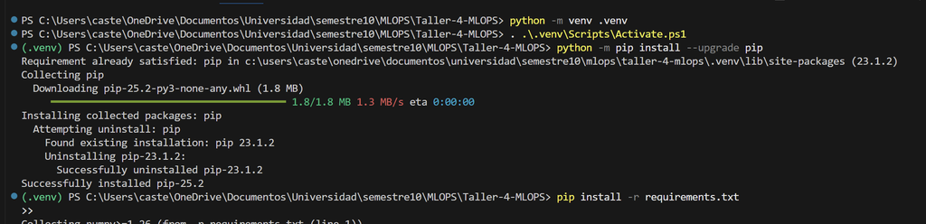

[figure not shown]

## Ejecución del pipeline con el ambiente

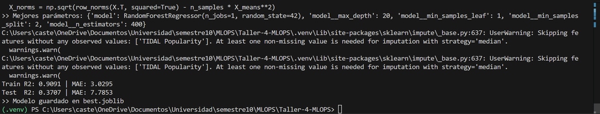

# Ambiente con Conda

## Creación

[figure not shown]

## Instalación

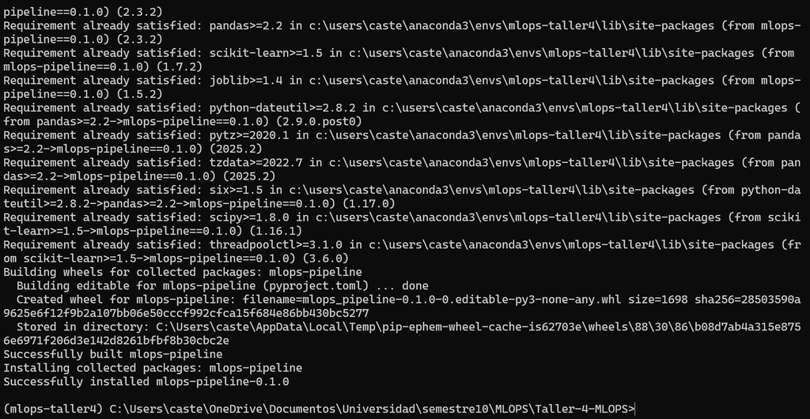

## Ejecución

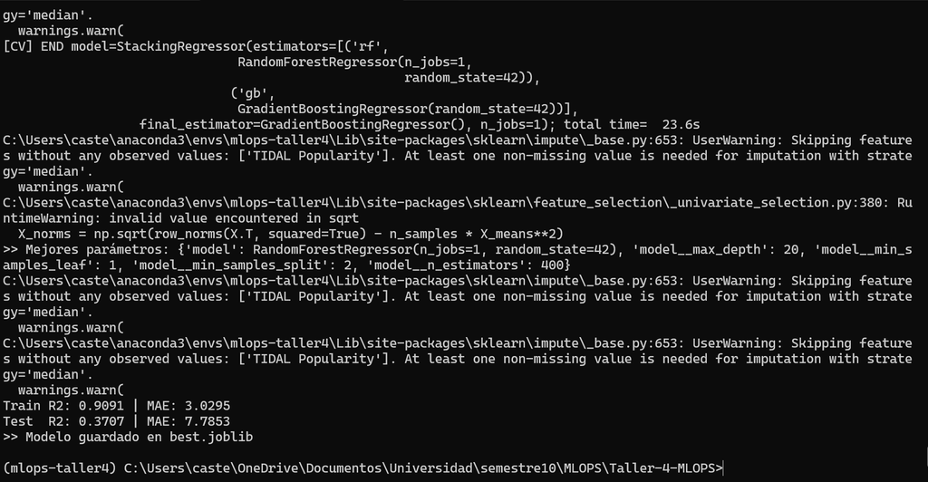